# A Dive Into Autoencoders

Elvira Fleury and Rachel Slimovitch

## What are autoencoders?

An autoencoder is a type of neural network that learns efficient representations of the input data. In this post, we will explain traditional autoencoders, which use a feedforward network structure with the same number of nodes in the input and output layer. Note that there are variations such as recurrent or variational autoencoders that deviate from a purely feedforward neural network, but we will not discuss them in this post.

The role of the autoencoder is to try and re-create the inputs by utilizing an hidden layer, $h$, called the “latent layer”, or a “bottleneck” layer. There are two main parts of the autoencoder algorithm: the encoder function $h=f(x))$, which converts $x$ inputs into codings in the latent layer; and the decoder function $x'=g(h)$, which reconstructs the inputs from the codings in the latent layer (1).

Autoencoders are unsupervised as they learn to reconstruct input without relying on explicit labels. The diagram below provides a schematic representation of the autoencoder architecture, where there are x inputs and x’ outputs:

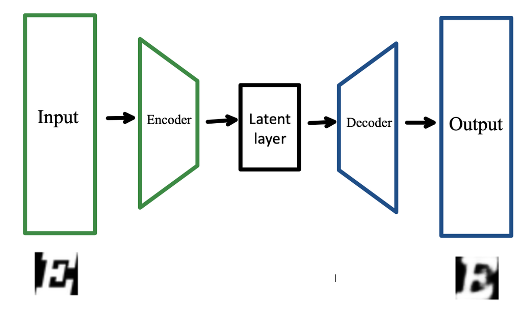

Autoencoders are typically trained with only one hidden layer as seen in the diagram above. However, they can have multiple hidden layers and are thus referred to as “stacked” or “deep” autoencoders. The additional depth allows the codings to take on more complex relationships but it is computationally expensive. In our project, we will demonstrate stacked autoencoders as our encoder and decoder have two hidden layers.

Our feedforward network is trained to be able to reconstruct the input data as best as possible. To accomplish this, the autoencoder attempts to minimize a loss function such as the mean squared error or binary cross-entropy:
$$minimize\ L = f(x,x')$$
, where $x'$ represents the output layer and is equivalent to $g(f(x))$.

Depending on the architecture and activation functions used, autoencoders can be linear or nonlinear. Autoencoders are linear when they use only linear activation functions and rely on MSE as the loss function. In this case, the latent layer will be identical to Principal Component Analysis (2). In our example, we will be using a non-linear autoencoder, and comparing the latent layer to PCA.

While we’ve focused on explaining autoencoders as attempting to copy the input from the output, we rarely use autoencoders for this purpose. We are typically more interested in the layer between the encoder and decoder, which we referred to above as the latent layer. The latent layer captures the underlying structure of the input data. Traditional autoencoders are undercomplete, meaning that the dimensionality of the inner representation is smaller than the input data. In this case, the latent layer is forced to capture the most dominant features of the input data. We will focus on undercomplete autoencoders for this post.

We will use Not-MNIST data to explore different uses of autoencoders. The Not-MNIST dataset is a collection of over 17,000 grayscale images of letters A through J, written in a variety of fonts, styles, and handwriting (3) It contains more variation than the MNIST data, making it a more realistic example for pattern recognition and classification. We will start by using the data to explain how to fit a traditional autoencoder. We will then use the data to explore three applications of autoencoders: anomaly detection, denoising, and dimension reduction. We’ll conclude by exploring additional public health applications of autoencoders. Please note that the code we use to build our simple autoencoder has been adapted from the following resource (4).

## Fitting a traditional autoencoder:

As with any data science application, the first (and perhaps most time intensive) step is to load in the data and process it so that it can be used for the model. A flowchart describing the pre-processing is included here, and the code can be found in the appendix. This preprocessing is done because the autoencoder will “expect” one row per image, with 784 columns. Each column will correspond to one of the pixels from the original 28-by-28 images.

Additionally, at this point, we create a vector of the letters represented by each image. Although this is not necessary for training the autoencoder (see “unsupervised” explanation above), it will be helpful for visualizing the latent layers later on, and may help us try to make sense of the lower-dimensional representation of the data.

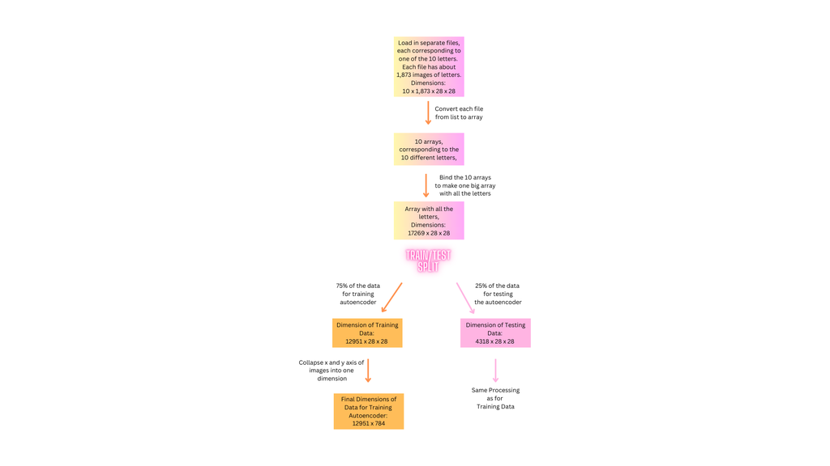

Next, to confirm that everything worked according to plan, we can plot the range of pixel values. After looking at a couple of the images, it seems that there is very little gray in the images. It’s mostly white and black, with white letters on a black background. Thus, we would expect to see two peaks-one at 0 and one at 1.

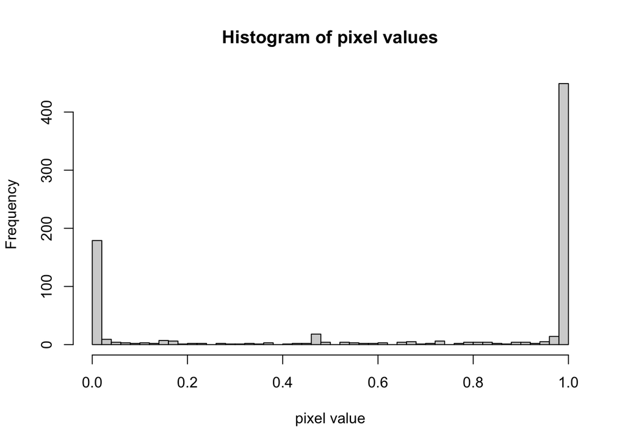

The plot looks like what we would expect it to! Another note is that we recommend routinely visualizing the images (or, more broadly, the data) throughout the process of getting it into the correct format for training your autoencoder (or any other model). We originally used another approach to get the data into array format-after we plotted one of the images, we saw that it was just static. Generally, it’s good to check- it would be terrible to fit a model on corrupted data and not understand why you are getting strange results.

```r
# Print the dimensions of the reshaped training data (x_train) for verification
dim(x_train)
```

```
## [1] 12951   784
```

```r
# Print the dimensions of the reshaped testing data (x_test) for verification
dim(x_test)
```

```
## [1] 4318  784
```

After printing the dimensions we see that we now have an array whose dimensions correspond to 1) the number of images in each set, and 2) the total number of pixels in each image. As mentioned above, this is the final format that we will use as input for the autoencoder.

Now that we have our data in the two dimensional array format, we can start defining the architecture of the model. The input layer of the autoencoder should be as many pixels as there are in the images. Here, the images are 28 pixels long and 28 pixels wide. Thus, our input layer should have 28*28, or 784 nodes. For this initial demonstration, we will be building an autoencoder with a very simple architecture: we will be building a symmetrical stacked autoencoder (i.e. the architecture of the encoder is the mirror image of the decoder). The encoder will have a 784 node input layer, 256 node hidden layer, followed by another hidden layer with 128 nodes, and a final 10 node latent layer.

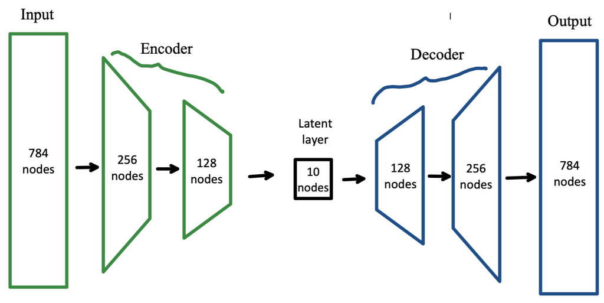

Finally before we fit our neural network, we should discuss “hyperparameters”, which are parameters that determine the characteristics of our model. Above, we can see that we chose to have a ten node latent layer, and a total of five hidden layers. These choices, of course, are not set in stone. The process of deciding which architecture to use is called “hyperparameter tuning”. Choices that you can make include: | - the number of layers in the model | - the width of the layers (i.e. the number of nodes in each layer) | - whether to include dropout or regularization to prevent overfitting.

These choices are usually made by trying various combinations of layers, width, dropout and regularization. This is sometimes called a parameter sweep or grid search. Although we will not present a full parameter sweep here, we present how an autoencoder with a 10-node bottleneck layer performs relative to an autoencoder with a 2-node bottleneck layer. Note how both the loss in the training set (blue) and the loss on unseen validation/test data (green) is greater in the model with the two-node bottleneck layer (33.80% and 35.16% respectively) relative to the model with the ten-node bottleneck layer (20.11% and 21.23% respectively). As we see below, using 10 nodes in the latent layer allows us to capture the essential information needed for accurate image reconstruction, without resulting in overfitting on the training data. The not-MNIST data has a strong inherent structure: thus it is relatively easy for our autoencoder to learn meaningful representations with only ten nodes in the latent layer.

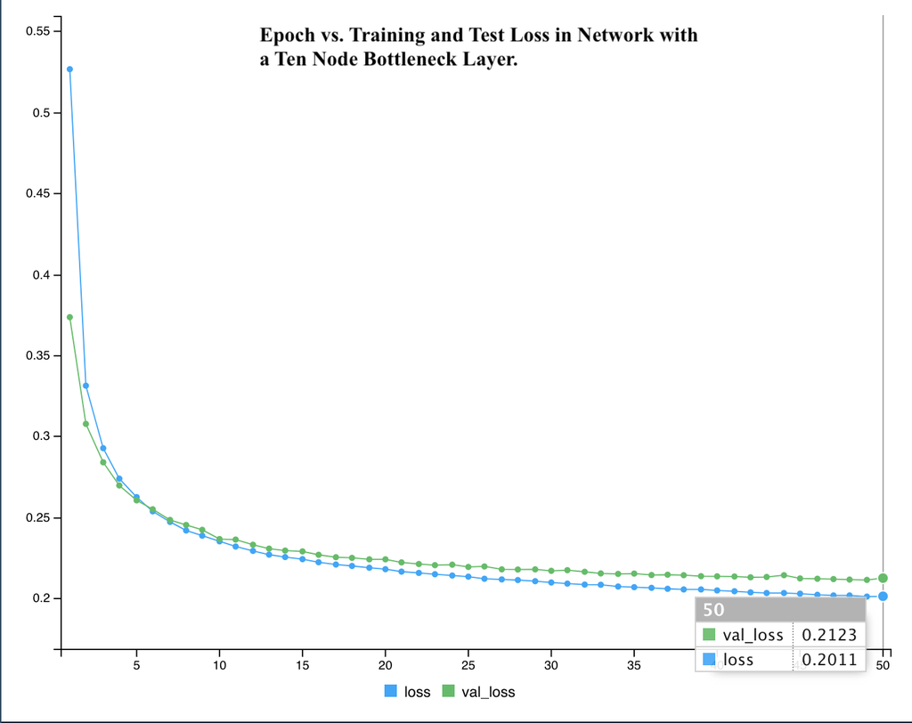

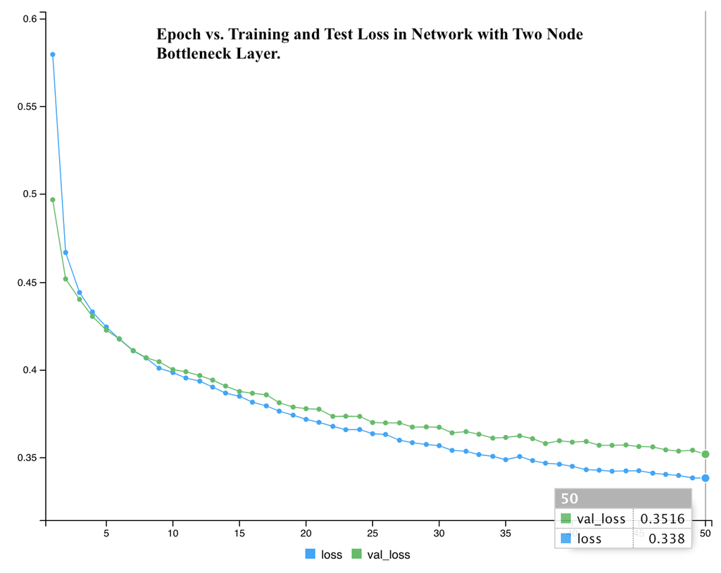

Later on in this post, we will cover an example of a paper that used autoencoders and discuss how they conducted their parameter sweep.

```r
set.seed(0417)
latent_size<- 10 #this is the size of the bottleneck
#ENCODER
#define input layer:
enc_input<-layer_input(shape=c(input_size)) #our input is the 28x28 pixels

#define other layers in encoder:
enc_output = enc_input %>% #first layer with pixels
  layer_dense(units=256, activation = "relu") %>% #hidden layer of the encoder
  layer_activation_leaky_relu() %>% #leaky relu prevents "dying nodes"
  layer_dense(units=128, activation = "relu") %>% #hidden layer of the encoder
  layer_activation_leaky_relu() %>%
  layer_dense(units=latent_size) %>% # "bottleneck" layer.
  layer_activation_leaky_relu()

encoder = keras_model(enc_input, enc_output)
summary(encoder)
```

```
## Model: "model"
## ________________________________________________________________________________
##  Layer (type)                       Output Shape                    Param #
## ================================================================================
##  input_1 (InputLayer)               [(None, 784)]                   0
##  dense_2 (Dense)                    (None, 256)                     200960
##  leaky_re_lu_2 (LeakyReLU)          (None, 256)                     0
##  dense_1 (Dense)                    (None, 128)                     32896
##  leaky_re_lu_1 (LeakyReLU)          (None, 128)                     0
##  dense (Dense)                      (None, 10)                      1290
##  leaky_re_lu (LeakyReLU)            (None, 10)                      0
## ================================================================================
## Total params: 235,146
## Trainable params: 235,146
## Non-trainable params: 0
## ________________________________________________________________________________
```

Next, using much the same code, we create the decoder. Remember: the decoder will have the “mirror image” architecture of the encoder.

```r
set.seed(0417)
dec_input = layer_input(shape = latent_size) #our input is that latent/bottle neck size

dec_output = dec_input %>%
  layer_dense(units=128, activation = "relu") %>%
  layer_activation_leaky_relu() %>%
  layer_dense(units=256, activation = "relu") %>%
  layer_activation_leaky_relu() %>%
  layer_dense(units = input_size, activation = "sigmoid") %>%  #our output is the original input, and sigmoid b/c forces output to be between 0 and 1
  layer_activation_leaky_relu()

decoder = keras_model(dec_input, dec_output)

summary(decoder)
```

```
## Model: "model_1"
## ________________________________________________________________________________
##  Layer (type)                       Output Shape                    Param #
## ================================================================================
##  input_2 (InputLayer)               [(None, 10)]                    0
##  dense_5 (Dense)                    (None, 128)                     1408
##  leaky_re_lu_5 (LeakyReLU)          (None, 128)                     0
##  dense_4 (Dense)                    (None, 256)                     33024
##  leaky_re_lu_4 (LeakyReLU)          (None, 256)                     0
##  dense_3 (Dense)                    (None, 784)                     201488
##  leaky_re_lu_3 (LeakyReLU)          (None, 784)                     0
## ================================================================================
## Total params: 235,920
## Trainable params: 235,920
## Non-trainable params: 0
## ________________________________________________________________________________
```

Now that we have coded the encoder and decoder, we are ready to combine them to make our final autoencoder.

```r
aen_input = layer_input(shape = input_size) #original input: 28x28

aen_output = aen_input %>% #original input
  encoder() %>%  #encoder
  decoder() #decoder

aen = keras_model(aen_input, aen_output)
summary(aen)
```

```
## Model: "model_2"
## ________________________________________________________________________________
##  Layer (type)                       Output Shape                    Param #
## ================================================================================
##  input_3 (InputLayer)               [(None, 784)]                   0
##  model (Functional)                 (None, 10)                      235146
##  model_1 (Functional)               (None, 784)                     235920
## ================================================================================
## Total params: 471,066
## Trainable params: 471,066
## Non-trainable params: 0
## ________________________________________________________________________________
```

The total number of parameters in our autoencoder is equal to the sum of the trainable parameters in the encoder and the decoder. In total, there are 471,066 trainable parameters. Thank goodness for computers, right? We are ready to “fit” our autoencoder.

Each weight and bias (trainable parameter) is initialized randomly. What happens next is that using these random parameters, the neural network takes the 784 input pixels, repeatedly takes their weighted sum according to the parameters and returns the final transformed output. Here, the goal of the neural network is to take the input, take it to a lower dimension, then return to the original dimension. Thus, the “y” variable is actually the input. As you may guess, since the weights and biases were initialized randomly, the output will not look anything like the input! This “difference” between the original input and the output is how we will know that we have to update the weights and biases. The larger the difference, the worse the network did, the more we have to change.

Here, the difference is measured using binary cross entropy. Binary cross entropy is a commonly used loss function (i.e. way of quantifying the difference between our predicted output and the true output) in classification tasks where the output is expected to be a value between 0 and 1.

Given a set of true binary labels y (where y can be either 0 or 1) and the predicted probabilities p for each pixel, the binary cross-entropy loss is calculated as follows:

$$Binary\ Cross\ Entropy(y, p) = -[y * log(p) + (1-y)*log(1-p)]$$

This loss function has the following characteristics:

- When the true value is close to the predicted value the loss will be close to 0, which indicates a good prediction.  
- When the true value is far from the predicted value, the loss will be close to 1, indicating a poor prediction.

Putting everything into context, our goal is to have a model with a binary crossentropy value as close to 0 as possible. If the value of the loss function is closer to 1, we aim to adjust the weights and biases to bring it closer to 0. This presents an optimization problem: how can we modify the weights and biases to minimize the loss function value? We compute the desired “change” in the weights and biases using backpropagation. While we won’t delve into the specifics of backpropagation here, a helpful high-level discussion and visualization can be found at (5).

In order to accelerate the training process, we use a smaller subset of samples, called a “batch”, instead of processing all 12,951 rows at each epoch. This approach allows the network to compute output predictions, the loss function, and gradients more efficiently. A larger batch size offers a more accurate gradient estimate but demands more memory and computational resources. Conversely, a smaller batch size can result in faster updates, albeit with noisier gradients and potentially less stable convergence.

After calculating the gradients with backpropagation, the ADAM optimizer takes charge of updating the weights and biases. It considers not only the current gradients but also the historical gradients to make these updates. By incorporating historical gradients, ADAM enables a more efficient and effective training process.

In summary, by processing a subset of samples, backpropagation calculates the gradients of the loss function concerning each weight and bias. Subsequently, ADAM utilizes these gradients to update the parameters in a manner that expedites convergence and enhances the performance of training deep neural networks.

Thus, we are ready to fit our network to minimize the difference between the output layer and the input layer all while passing through a lower dimension.

```r
#Fitting the model
aen %>% compile(
  optimizer = 'adam',  #note that the website used rmsprop instead, could choose either
  loss = 'binary_crossentropy',
)

#Train the model:
aen %>% fit(x= x_train,
            y= x_train,  #note that y is same as x b/c in autoencoders, goal is to reconstruct input
            epochs=50, #number of times we feed forward and use backprop to change the weights and biases
            batch_size=256,
            validation_data= list(x_test, x_test))
```

Now the autoencoder has been fit :). The next step is to see how it does taking unseen images of letters to a lower dimension and then reconstructing them.

First, we encode the 4,318 images in the test data.

```r
encoded_imgs <- encoder %>%
                predict(x_test)
dim(encoded_imgs)
```

```
## [1] 4318   10
```

The output is 4,318 by 10. This is because each image has been taken from having 784 dimensions to ten dimensions corresponding to the ten hidden nodes. Next, we pass these encoded images through the decoder.

```r
#decoder
decoded_imgs<- decoder %>%
               predict(encoded_imgs) #predicting on the output of the encoder
```

Now that we have the decoded images, the final step is to convert the data to 4318 by 28 by 28 again so that we can plot the images and see how we did!

```r
#change shape of the decoded data: back to 10,000 x 28 x 28, currently 10,000 x 784
pred_images = array_reshape(decoded_imgs, dim=c(dim(decoded_imgs)[1], 28, 28))
```

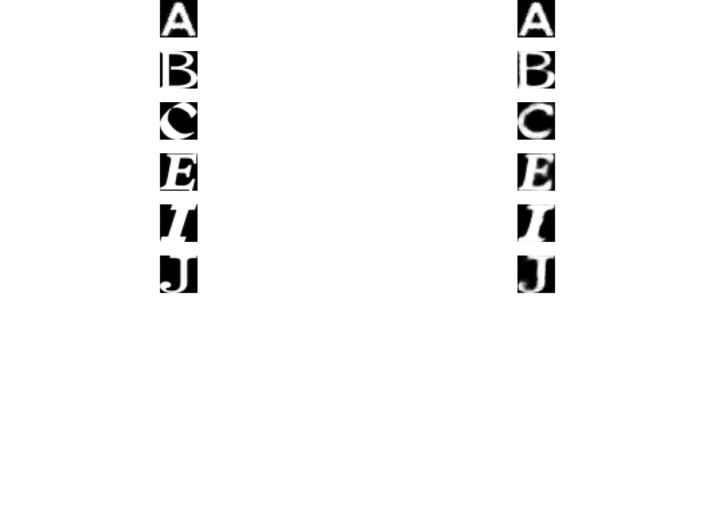

```r
op <- par(mfrow=c(10,2), mar=c(1,0,0,0)) #setup: 12 images in each of 2 columns
letters_to_test<- c(4, 789, 977, 2345,3487 , 4256)
#loop through 1-10:
for (i in letters_to_test){
  plot(as.raster(xtest[i,,]))
    plot(as.raster(pred_images[i,,]))
}
```

## Anomaly Detection

*Anomaly Detection in not-MNIST*

Now we will demonstrate the usefulness of autoencoders for anomaly detection.

This is done by first calculating the reconstruction error for each image in the test data, and then pulling out the images with the greatest reconstruction error. The idea behind this is that the images with the greatest reconstruction error will be letters that least follow the pattern that the network has learned.

For each sample i in the test set, the reconstruction error $E_{i}$ is calculated using the following formula:

$E_i = \sqrt{\sum (x_{test_{i}} - decoded_{imgs_{i}})^2}$

```r
reconstruction_errors <- apply(X = x_test - decoded_imgs, MARGIN = 1, FUN = function(x) sqrt(sum(x^2)))
```

```r
threshold <- quantile(reconstruction_errors, probs = 0.999)
# Step 3: Identify the indices of the images with reconstruction errors greater than the threshold value
anomaly_indices <- which(reconstruction_errors > threshold)
```

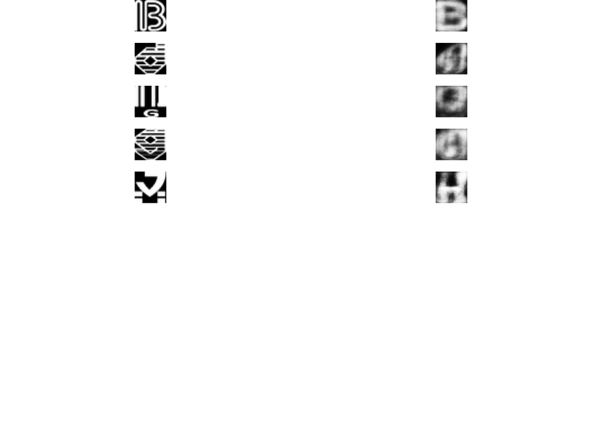

```r
op <- par(mfrow=c(10,2), mar=c(1,0,0,0)) #setup: 12 images in each of 2 columns
#loop through 1-10:
for (i in anomaly_indices){
  plot(as.raster(xtest[i,,]))
    plot(as.raster(pred_images[i,,]))
}
```

*Anomaly Detection with MNIST*

In this section, we demonstrate the utility of autoencoders for anomaly detection by introducing entirely different inputs. The MNIST dataset is a widely-used dataset for learning machine learning techniques. It is remarkably similar to the not-MNIST dataset (hence the name), but it contains images of handwritten digits rather than letters.

To showcase anomaly detection, we will add 10 images from the MNIST dataset, assuming that when the autoencoder attempts to reconstruct images of digits using the patterns it learned for letters, the reconstruction error will be significant. This large reconstruction error is expected to be noticeably higher compared to the error observed when passing images of letters through the autoencoder. Consequently, the substantial difference in reconstruction error can be used to identify anomalies in the input data.

```r
#load mnist
mnist <- dataset_mnist()
X_train <- mnist$train$x
X_test <- mnist$test$x
y_train <- mnist$train$y
y_test <- mnist$test$y
```

```r
#doesn't matter which we use (train vs. test), and we don't need the y's since we aren't actually doing classification
#so I'm just going to select 10 images from X_train

x_mnist<- X_train[1:10, , ] #select images

x_mnist = array_reshape(x_mnist, dim=c(dim(x_mnist)[1], 784)) #reshape the 10 images

rm(mnist, X_train, X_test, y_train, y_test) #remove the rest of the data
```

```r
with_mnist<- abind(x_test,x_mnist, along=1) #add mnist to not-mnist
```

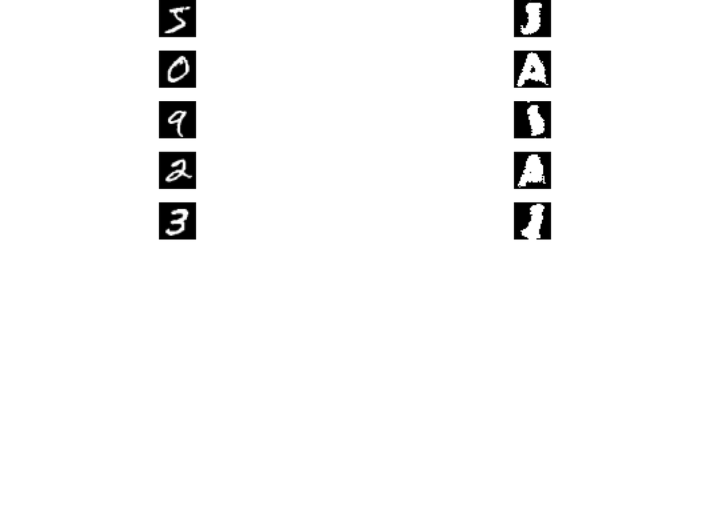

```r
encoded_with_mnist <- encoder %>%
                predict(with_mnist)
decoded_with_mnist<- decoder %>%
               predict(encoded_with_mnist)

mnist_reconstruction_errors <- apply(X = with_mnist - decoded_with_mnist, MARGIN = 1, FUN = function(x) sqrt(sum(x^2)))
mnist_threshold <- quantile(mnist_reconstruction_errors, probs = 0.999)
# Step 3: Identify the indices of the images with reconstruction errors greater than the threshold value
mnist_anomaly_indices <- which(mnist_reconstruction_errors > mnist_threshold)

mnist_pred_images = array_reshape(decoded_with_mnist, dim=c(dim(decoded_with_mnist)[1], 28, 28))
with_mnist_2 = array_reshape(with_mnist, dim=c(dim(with_mnist)[1], 28, 28))

normalized_with_mnist_2 <- with_mnist_2 / max(with_mnist_2)
normalized_mnist_pred_images <- mnist_pred_images / max(mnist_pred_images)

op <- par(mfrow=c(10,2), mar=c(1,0,0,0)) #setup: 12 images in each of 2 columns
#loop through 1-10:
for (i in mnist_anomaly_indices){
  plot(as.raster(normalized_with_mnist_2[i,,]))
  plot(as.raster(normalized_mnist_pred_images[i,,]))
}
```

As we can see above, the inputs with the greatest reconstruction error are now numbers instead of letters. Pretty nifty!

Readers who are interested in learning more about the seminal work and theory behind autoencoders for anomaly detection are encouraged to read the following papers: | - Sakurada and Yairi, 2014 (6) | - Zhou and Paffenroth, 2017 (7)

## Denoising

Autoencoders can also be used for denoising. In denoising, our input data is corrupted and the autoencoder is trained to reconstruct the clean version of the input (2). Denoising is one strategy for tackling the bias-variance tradeoff with autoencoders: we want our model’s architecture to be robust enough to minimize reconstruction error, but we also want to make sure that our model is generalizable and isn’t overfitting on the training data. Denoising prevents our autoencoder from simply memorizing the training data. In our example we showed above, by feeding in clean images into our autoencoder and minimizing the loss function $L(x, g(f(x)))$, our model is incentivized to have $g \circ f$ to be the identity function (2). By feeding in corrupted images instead, our loss function becomes $L(x,g(f(\tilde{x})))$, where $\tilde{x}$ is the copy of the original inputs, $x$ that have been corrupted. To be clear, $f(\tilde{x}$ is the encoder function, and $g(f(\tilde{x}))$ is the decoder function.

Putting this all together, we re-train the network using the corrupted images as the input, and to calculate the loss, we compare the output from the corrupted images to the original uncorrupted images. A visual representation of how autoencoders for denoising work can be seen below.

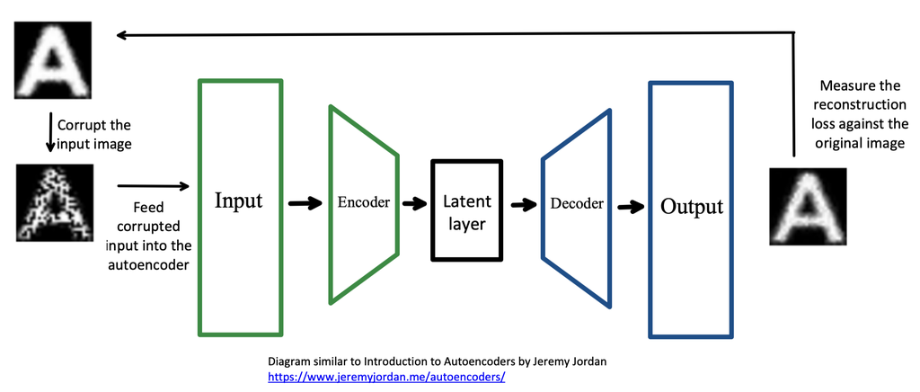

(8)

To show how autoencoders can be used for denoising, let’s first “corrupt” the images that we tested above. This will be done by randomly setting 20% of the pixels in the input to 0, and another 20% to 1.

```r
set.seed(0417)
corrupt_image<- function (input){
  res_mat<- matrix(NA, nrow=nrow(input), ncol=784) #store corrupted image
  for (i in 1:nrow(input)){
    pixels_to_corrupt<- sample(1:784, .4*(784), replace = FALSE) #randomly select 40% to corrupt
    pixel_to_corrupt_1<- sample(pixels_to_corrupt, .5*0.4*784, replace = FALSE) #randomly select 50% of those to set to 1
    pixel_to_corrupt_0<- pixels_to_corrupt[-pixel_to_corrupt_1]# set remaining to 0

  for(j in 1:784){
    if(j %in% pixel_to_corrupt_0){res_mat[i,j]<- 0} #if in 0 vector set to 0
    else if (j %in% pixel_to_corrupt_1){res_mat[i,j]<- 1}
    else{res_mat[i,j]<- input[i,j]}
    }
  }
  return(res_mat)
}

x_train_corrupt<- corrupt_image(x_train)
x_test_corrupt<- corrupt_image(x_test)
```

Now that we have corrupted the images, we can go ahead and pass them though the autoencoder and compare the output to the corrupted input!

```r
#Fitting the model
aen %>% compile(
  optimizer = 'adam',  #note that the website used rmsprop instead, could choose either
  loss = 'binary_crossentropy', #the website used binary_crossentropy
)

#Train the model:
aen %>% fit(x= x_train_corrupt,
            y= x_train,  #b/c in autoencoders, goal is to reconstruct input
            epochs=100, #number of times we feed forward and use backprop to change the weights and biases
            batch_size=256)
```

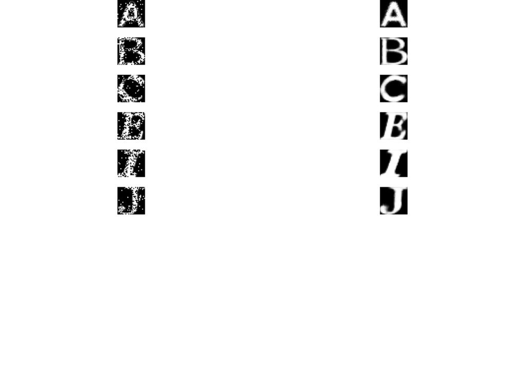

```r
encoded_corrupted_imgs <- encoder %>%
                predict(x_test_corrupt)
decoded_corrupted_imgs<- decoder %>%
               predict(encoded_corrupted_imgs)
pred_corrupted_images = array_reshape(decoded_corrupted_imgs, dim=c(dim(decoded_corrupted_imgs)[1], 28, 28))
corrupted_images = array_reshape(x_test_corrupt, dim=c(dim(x_test_corrupt)[1], 28, 28))

op <- par(mfrow=c(10,2), mar=c(1,0,0,0)) #setup: 12 images in each of 2 columns
#loop through 1-10:
for (i in letters_to_test){
  plot(as.raster(corrupted_images[i,,]))
    plot(as.raster(pred_corrupted_images[i,,]))
}
```

Above, we can see that the “noise” we introduced has been removed from the images.

While denoising is one strategy for dealing with the bias-variance tradeoff, there are also other approaches. One approach to deal with the bias-variance tradeoff is by using contractive autoencoders. Contractive autoencoders introduce a regularizer on the encoder, constraining the derivatives to be small with respect to the inputs. This allows our model to learn robust representations and be less affected by minor input variations (9). Another approach to the bias-variance tradeoff is to use sparse autoencoders, which enforce sparsity on the layers between the input and output layer. Sparsity is most commonly enforced through one of two methods: the Kullback-Leibler divergence (KL divergence), which measures the divergence between the target probability that a node will activate and the actual probability it will activate; or L1 regularization, which pushes the weights of some of the nodes towards zero (2). Both strategies force the autoencoder to learn a minimally activated representation of the input. While we will not discuss contractive or sparse autoencoders further, you can find more information here (1)

## Dimension Reduction

Autoencoders can be used for dimension reduction by extracting the compressed representation from the latent layer. To allow us to visualize this compressed representation, we will recreate our autoencoder architecture by utilizing a latent layer of only 2 nodes.

In this example, we will show how using non-linear autoencoders for dimension reduction can give vastly different results than utilizing PCA. As a reminder, PCA is a dimension reduction technique that uses a linear map to maximize the variance in the data. (Recall in the introduction that using linear activation and the MSE with autoencoders would give the same result as PCA.) The following is a visualization of how autoencoders can learn information more adeptly than PCA when faced with non-linear data:

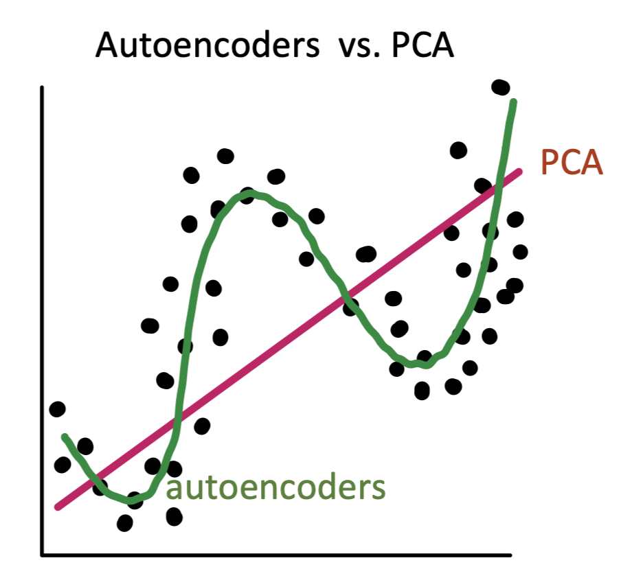

We used the training data to fit our updated autoencoder model with 2 nodes in the latent layer. During this process, our autoencoder learns how to create a compressed representation of the input letters by capturing important features such as strokes, shapes, or angles. We then used the encoder on our test set to predict the latent layer. The following is a visualization of the data (colored by letter) in the latent layer, where the x-axis represents the first node and the y-axis represents the second node:

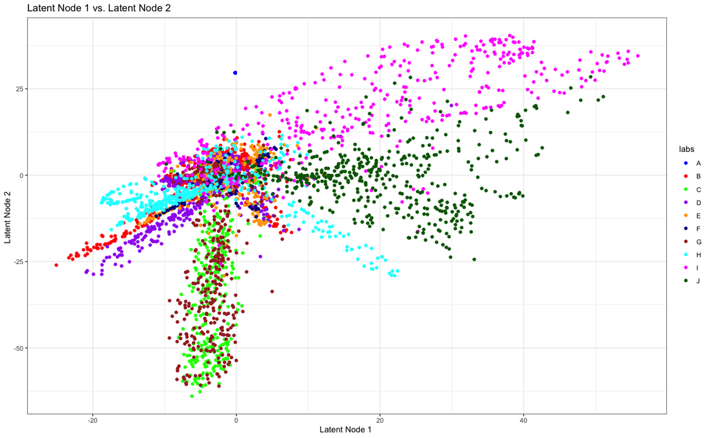

We see that using only two nodes, our autoencoder was able to create a compressed representation of the data that clusters images of the same letters together. This is exciting- our autoencoder was able to pick up on enough important features in the latent layer to capture how images representing the same letter are similar!

We also see that similar letters like C (light green) and G (dark red) have overlapping clusters. Our autoencoder recognizes shared features between these letters- like the curved shape- and assigns them very similar values in the latent layer. This plot also reveals other interesting findings; for example, we see two distinct groupings of H. Our plot is likely picking up on some systemic difference; for example, it could be discerning that some of H images have very thick white lines while others have thin white lines.

We then ran PCA on our test data to demonstrate how it is suboptimal when compared to autoencoders for dimension reduction on non-linear data. The following is a plot of the first two principal components, colored by letter:

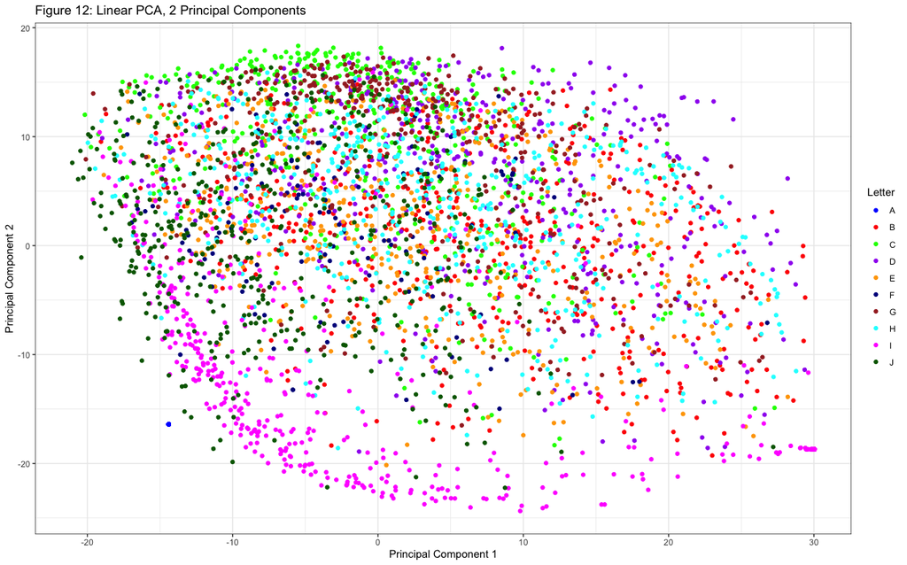

Unlike our autoencoder plot, we see that PCA struggled to cluster images of the same letter. While it somewhat accomplished this with I (in pink), all other letters are scattered throughout the plot. This makes sense: when it comes to grouping over 4,300 images representing letters A-J, identifying which images correspond to the same letter is not a linear task. While standard PCA will not be able to recognize non-linear relationships, autoencoders will be able to.

Siwek and Osowski also found the autoencoders were superior to PCA in their paper on dimension reduction for facial recognition. Using images representing faces of 51 different people, they found the standard deviations of the feature values for images representing the same person was significantly smaller and more balanced with autoencoders than with PCA (10). While the benefit of PCA is simplicity and computational efficiency, other methods such as autoencoders should be used when performing dimension reduction on non-linear data.

## Autencoder Extensions

*Summarizing Public Health Research that Has Used Autoencoders*

While we’ve explained how autoencoders can be used with the not-MNIST data, autoencoders can also be extended to many public health applications. We will detail how autoencoders can be used for medical imaging as well as missing data imputation.

**Paper 1:** [“Anomaly Detection in Medical Imaging with Deep Perceptual Autoencoders”] (#https://arxiv.org/abs/2006.13265) Shvetsova et al., 2021 (11)

Shvetsova et al. (2021) explored how deep perceptual autoencoders can be used for anomaly detection in medical imaging. Specifically, they examined anomaly detection on chest X-rays, which are one of the most common methods for diagnosing lung disease. Recognizing that barely visible abnormalities in chest X-rays can be very challenging to detect, Shvetsova et al. (2021) proposed a new approach utilizing autoencoders where they introduced a small number of anomalies into the training data rather than using no abnormal examples during the model setup. The equivalent to this in our anomaly detection example with not-MNIST data would be if we had introduced partial letters, or strongly distorted letters, into our training data for our model setup. They experimented with utilizing abnormal X-rays for 0.5% of the training data. The goal of introducing these anomalies into the training data was to strengthen the selection of optimal model hyperparameters, such as the depth, width, or batch size. Specifically, they included anomalies with confined variability into the training data in order to provide the model with a representative sample of real-world X-rays. In the results, Shvetsova et al. (2021) found that introducing this small number of anomalies with confined variability in the model setup helped improve the model’s ability to detect anomalies in the chest X-ray test images. While other methods in this paper such as deep perceptual autoencoders are beyond the scope of this post, the main takeaways is that the infrastructure of how autoencoders can be used for anomaly detection is constantly evolving.

**Paper 2:** [“Missing Data Imputation in the Electronic Health Record Using Deeply Learned Autoencoders”] (https://pubmed.ncbi.nlm.nih.gov/27896976/) (12) Beaulieu-Jones and Moore, 2017.

In this study, the authors compared the performance of a deep autoencoder with dropout to other common imputation techniques to impute electronic health record data (EHR) that was artificially missing both completely at random and not at random. The different imputation techniques were then compared for their ability to predict ALS disease progression.

Before delving into the autoencoder that the authors used, we should quickly cover the different ways that data can be missing. Two scenarios are studied in this paper: missing completely at random (MCAR), and missing not at random (MNAR). Data is said to be missing completely at random if there is “no systematic determination of whether a value is missing or present. The likelihood is independent of the data and any latent information” (12). Conversely MNAR data occurs when “data is missing due to either observed values in the data or unobserved latent values” (12). As we covered earlier in this post, denoising autoencoders are autoencoders that are trained on data that has has added noise to corrupt a portion of the inputs. The authors summarized the step from denoising to imputation beautifully: “Because autoencoders learn by reconstructing the original input from a corrupted version, imputation is a natural extension”.

The authors used a subset of the PRO-ACT dataset, a dataset designed to empower translational ALS research. Before training the network, categorical variables were one-hot encoded, scales were standardized, variables were put in the right format (i.e. numeric), and temporal/repeated measurements were summarized.

The authors did a parameter sweep to determine the ideal architecture for their autoencoder. They tested different combinations of layers, nodes, and levels of dropout to determine the optimal architecture. Ultimately, they chose a network with two hidden layers, with 500 nodes each and 20% dropout between the layers. Furthermore, similar to how we calculated the cost for our network, the authors used a modified version of binary cross entropy. Their modified function takes into account missing data, and represents the average cost per feature.

The authors compared the neural network to 1) Iterative SVD, 2) K-nearest neighbors imputation, 3) SoftImpute, 4) column mean filling, and 5) column median filling. The authors then “spiked-in” missing data. To simulate data that was missing completely at random, they randomly selected features and replaced a fraction with NaN. To simulate data that was not missing at random, the authors randomly selected a fraction of the features and and replaced the highers or lowest quartile of values with NaN. The models were compared using root mean squared error between the imputed values and the original data. A helpful scheme, taken from the paper (12), can be seen below.

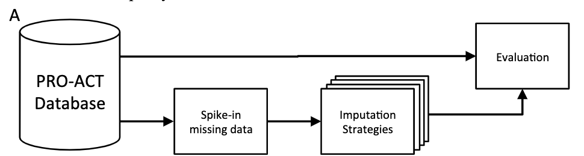

The authors found that when the data was MCAR, “the autoencoder had the highest imputation performance” despite decreasing in performance as the number of missing features increased. Similarly, when the data was missing MNAR, the autoencoder had the best performance despite, again, performing worse as the proportion of missing features increased.

Ultimately, our hope is that after reading this blog post, readers will be able to approach autoencoders in literature, such as in this study, and feel sufficiently confident to understand how they were implemented, and ,perhaps, feel as though they could implement them themselves. Finally, we hope that although we demonstrated a limited range of uses for autoencoders, the reader will be able to understand how these uses can be expanded, such as going from denoising to imputation.

## Citations

1. Goodfellow, I., Bengio, Y., & Courville, A. (2016). Chapter 14 Autoencoders | Deep Learning. MIT Press. http://www.deeplearningbook.org
2. Bank, D., Koenigstein, N., & Giryes, R. (2021). Autoencoders (arXiv:2003.05991). arXiv. https://doi.org/10.48550/arXiv.2003.05991
3. Bulatov, Y. (n.d.). NotMNIST Dataset. Kaggle. Retrieved May 13, 2023, from https://www.kaggle.com/datasets/lubaroli/notmnist
4. DataTechNotes: How to build simple autoencoder with Keras in R. (n.d.). Retrieved May 13, 2023, from https://www.datatechnotes.com/2020/02/how-to-build-simple-autoencoder-with-keras-in-r.html

(5)3Blue1Brown (Director). (2017, November 3). Backpropagation Calculus | Chapter 4, Deep Learning. https://www.youtube.com/watch?v=tIeHLnjs5U8

6. Sakurada, M., & Yairi, T. (2014). Anomaly detection using autoencoders with nonlinear dimensionality reduction. Proceedings of the MLSDA 2014 2nd Workshop on Machine Learning for Sensory Data Analysis, 4–11. https://doi.org/10.1145/2689746.2689747
7. Zhou, C., & Paffenroth, R. C. (2017). Anomaly detection with robust deep autoencoders. Proceedings of the 23rd ACM SIGKDD International Conference on Knowledge Discovery and Data Mining, 665–674. https://doi.org/10.1145/3097983.3098052
8. Jordan, J. (2018, March 19). Introduction to autoencoders. Jeremy Jordan. https://www.jeremyjordan.me/autoencoders/
9. Boehmke, B., & Greenwell, B. (n.d.). Chapter 19 Autoencoders | Hands-On Machine Learning with R. Retrieved May 13, 2023, from https://bradleyboehmke.github.io/HOML/autoencoders.html
10. Siwek, K., & Osowski, S. (2017). Autoencoder versus PCA in face recognition. 2017 18th International Conference on Computational Problems of Electrical Engineering (CPEE), 1–4. https://doi.org/10.1109/CPEE.2017.8093043
11. Shvetsova, N., Bakker, B., Fedulova, I., Schulz, H., & Dylov, D. V. (2021). Anomaly detection in medical imaging with deep perceptual autoencoders. IEEE Access, 9, 118571–118583. https://doi.org/10.1109/ACCESS.2021.3107163
12. Beaulieu-Jones, B. K., & Moore, J. H. (2017). Missing data imputation in the electronic health record using deeply learned autoencoders. Pacific Symposium on Biocomputing. Pacific Symposium on Biocomputing, 22, 207–218. https://doi.org/10.1142/9789813207813_0021

**CODE APENDIX**

```r
knitr::opts_chunk$set(echo = TRUE)
library(tensorflow)
library(keras)
library(ggplot2)
library(caret)
library(imager)
library(abind)
library(knitr)
knitr::include_graphics("intro_image.png")
knitr::include_graphics("data_processing_final.png")
load("~/Desktop/statistical learning and big data/final project data/A.RData")
load("~/Desktop/statistical learning and big data/final project data/B.RData")
load("~/Desktop/statistical learning and big data/final project data/C.RData")
load("~/Desktop/statistical learning and big data/final project data/D.RData")
load("~/Desktop/statistical learning and big data/final project data/E.RData")
load("~/Desktop/statistical learning and big data/final project data/F.RData")
load("~/Desktop/statistical learning and big data/final project data/G.RData")
load("~/Desktop/statistical learning and big data/final project data/H.RData")
load("~/Desktop/statistical learning and big data/final project data/I.RData")
load("~/Desktop/statistical learning and big data/final project data/J.RData")

#function that converts lists to array format
make_array<- function(letter_list){
  res_array<- array( 0, dim=c(length(letter_list), 28, 28)) #initialize an array
#loop through all images in list
for (i in 1:length(letter_list)){
  res_array[i,,] <- letter_list[[i]]
}
return(res_array)
}
#make arrays
A_array<- make_array(A)
B_array<- make_array(B)
C_array<- make_array(C)
D_array<- make_array(D)
E_array<- make_array(E)
F_array<- make_array(F)
G_array<- make_array(G)
H_array<- make_array(H)
I_array<- make_array(I)
J_array<- make_array(J)

rm(A, B, C, D, E, F, G, H, I, J) #clear workspace
#create label list
A_val<- rep("A",1873) #1873 images
B_val<- rep("B",1873) #1873 images
C_val<- rep("C",1873) #1873 images
D_val<- rep("D",1873) #1873 images
E_val<- rep("E",1873) #1873 images
F_val<- rep("F",416) #416 images
G_val<- rep("G",1872) #1872 images
H_val<- rep("H",1872) #1872 images
I_val<- rep("I",1872) #1872 images
J_val<- rep("J",1872) #1872 images
labels<- as.vector(c(A_val, B_val, C_val, D_val, E_val, F_val, G_val, H_val, I_val, J_val)) #all actual values
rm(A_val, B_val, C_val, D_val, E_val, F_val, G_val, H_val, I_val, J_val)
#bind all data together into one big array
all_data <- abind(A_array, B_array,
C_array, D_array, E_array, F_array,
G_array, H_array, I_array, J_array, along = 1)
rm(A_array, B_array, C_array, D_array, E_array, F_array,G_array, H_array, I_array, J_array ) #clear workspace

#test train split
set.seed(123)
# Get the number of samples
n_samples <- dim(all_data)[1]

# Sample indices for the training set
train_index <- sample(n_samples, 0.75 * n_samples, replace = FALSE)

# Split the data into training and testing sets
xtrain <- all_data[train_index, , ]
xtest <- all_data[-train_index, , ]
xtrain_labels<- labels[train_index]
xtest_labels<- labels[-train_index]

rm(train_index, all_data) #clear workspace

input_size<- dim(xtrain)[2] * dim(xtrain)[3] #total number of pixels in image

# Reshape the training and testing data:

# Reshape the training data (xtrain) by keeping the number of images as the first dimension
# and setting the second dimension to be equal to the total number of pixels (input_size, defined earlier)
x_train = array_reshape(xtrain, dim=c(dim(xtrain)[1], input_size))

# Print the dimensions of the reshaped training data (x_train) for verification
#dim(x_train)

# Reshape the testing data (xtest) in the same manner as the training data
x_test = array_reshape(xtest, dim=c(dim(xtest)[1], input_size))

# Print the dimensions of the reshaped testing data (x_test) for verification
#dim(x_test)
rm(xtrain)
hist(x_train[1,], breaks=50, main="Histogram of pixel values", xlab="pixel value")#definitely not ~N
# Print the dimensions of the reshaped training data (x_train) for verification
dim(x_train)
# Print the dimensions of the reshaped testing data (x_test) for verification
dim(x_test)

knitr::include_graphics("all_layers.png")
knitr::include_graphics("loss_ten_latent.png")
knitr::include_graphics("loss_two_latent.png")
set.seed(0417)
latent_size<- 10 #this is the size of the bottleneck
#ENCODER
#define input layer:
enc_input<-layer_input(shape=c(input_size)) #our input is the 28x28 pixels

#define other layers in encoder:
enc_output = enc_input %>% #first layer with pixels
  layer_dense(units=256, activation = "relu") %>% #hidden layer of the encoder
  layer_activation_leaky_relu() %>% #leaky relu prevents "dying nodes"
  layer_dense(units=128, activation = "relu") %>% #hidden layer of the encoder
  layer_activation_leaky_relu() %>%
  layer_dense(units=latent_size) %>% # "bottleneck" layer.
  layer_activation_leaky_relu()

encoder = keras_model(enc_input, enc_output)
summary(encoder)
set.seed(0417)
dec_input = layer_input(shape = latent_size) #our input is that latent/bottle neck size

dec_output = dec_input %>%
  layer_dense(units=128, activation = "relu") %>%
  layer_activation_leaky_relu() %>%
  layer_dense(units=256, activation = "relu") %>%
  layer_activation_leaky_relu() %>%
  layer_dense(units = input_size, activation = "sigmoid") %>%  #our output is the original input, and sigmoid b/c forces output to be between 0 and 1
  layer_activation_leaky_relu()

decoder = keras_model(dec_input, dec_output)

summary(decoder)
aen_input = layer_input(shape = input_size) #original input: 28x28

aen_output = aen_input %>% #original input
  encoder() %>%  #encoder
  decoder() #decoder

aen = keras_model(aen_input, aen_output)
summary(aen)

#Fitting the model
aen %>% compile(
  optimizer = 'adam',  #note that the website used rmsprop instead, could choose either
  loss = 'binary_crossentropy',
)

#Train the model:
aen %>% fit(x= x_train,
            y= x_train,  #note that y is same as x b/c in autoencoders, goal is to reconstruct input
            epochs=50, #number of times we feed forward and use backprop to change the weights and biases
            batch_size=256,
            validation_data= list(x_test, x_test))
encoded_imgs <- encoder %>%
                predict(x_test)
dim(encoded_imgs)
#decoder
decoded_imgs<- decoder %>%
               predict(encoded_imgs) #predicting on the output of the encoder
#change shape of the decoded data: back to 10,000 x 28 x 28, currently 10,000 x 784
pred_images = array_reshape(decoded_imgs, dim=c(dim(decoded_imgs)[1], 28, 28))
op <- par(mfrow=c(10,2), mar=c(1,0,0,0)) #setup: 12 images in each of 2 columns
letters_to_test<- c(4, 789, 977, 2345,3487 , 4256)
#loop through 1-10:
for (i in letters_to_test){
  plot(as.raster(xtest[i,,]))
    plot(as.raster(pred_images[i,,]))
}
reconstruction_errors <- apply(X = x_test - decoded_imgs, MARGIN = 1, FUN = function(x) sqrt(sum(x^2)))
```

```r
threshold <- quantile(reconstruction_errors, probs = 0.999)
# Step 3: Identify the indices of the images with reconstruction errors greater than the threshold value
anomaly_indices <- which(reconstruction_errors > threshold)
op <- par(mfrow=c(10,2), mar=c(1,0,0,0)) #setup: 12 images in each of 2 columns
#loop through 1-10:
for (i in anomaly_indices){
  plot(as.raster(xtest[i,,]))
    plot(as.raster(pred_images[i,,]))
}
#load mnist
mnist <- dataset_mnist()
X_train <- mnist$train$x
X_test <- mnist$test$x
y_train <- mnist$train$y
y_test <- mnist$test$y
#doesn't matter which we use (train vs. test), and we don't need the y's since we aren't actually doing classification
#so I'm just going to select 10 images from X_train

x_mnist<- X_train[1:10, , ] #select images

x_mnist = array_reshape(x_mnist, dim=c(dim(x_mnist)[1], 784)) #reshape the 10 images

rm(mnist, X_train, X_test, y_train, y_test) #remove the rest of the data
with_mnist<- abind(x_test,x_mnist, along=1) #add mnist to not-mnist
encoded_with_mnist <- encoder %>%
                predict(with_mnist)
decoded_with_mnist<- decoder %>%
               predict(encoded_with_mnist)

mnist_reconstruction_errors <- apply(X = with_mnist - decoded_with_mnist, MARGIN = 1, FUN = function(x) sqrt(sum(x^2)))
mnist_threshold <- quantile(mnist_reconstruction_errors, probs = 0.999)
# Step 3: Identify the indices of the images with reconstruction errors greater than the threshold value
mnist_anomaly_indices <- which(mnist_reconstruction_errors > mnist_threshold)

mnist_pred_images = array_reshape(decoded_with_mnist, dim=c(dim(decoded_with_mnist)[1], 28, 28))
with_mnist_2 = array_reshape(with_mnist, dim=c(dim(with_mnist)[1], 28, 28))

normalized_with_mnist_2 <- with_mnist_2 / max(with_mnist_2)
normalized_mnist_pred_images <- mnist_pred_images / max(mnist_pred_images)

op <- par(mfrow=c(10,2), mar=c(1,0,0,0)) #setup: 12 images in each of 2 columns
#loop through 1-10:
for (i in mnist_anomaly_indices){
  plot(as.raster(normalized_with_mnist_2[i,,]))
  plot(as.raster(normalized_mnist_pred_images[i,,]))
}

knitr::include_graphics("denoising_diagram.png")
set.seed(0417)
corrupt_image<- function (input){
  res_mat<- matrix(NA, nrow=nrow(input), ncol=784) #store corrupted image
  for (i in 1:nrow(input)){
    pixels_to_corrupt<- sample(1:784, .4*(784), replace = FALSE) #randomly select 40% to corrupt
    pixel_to_corrupt_1<- sample(pixels_to_corrupt, .5*0.4*784, replace = FALSE) #randomly select 50% of those to set to 1
    pixel_to_corrupt_0<- pixels_to_corrupt[-pixel_to_corrupt_1]# set remaining to 0

  for(j in 1:784){
    if(j %in% pixel_to_corrupt_0){res_mat[i,j]<- 0} #if in 0 vector set to 0
    else if (j %in% pixel_to_corrupt_1){res_mat[i,j]<- 1}
    else{res_mat[i,j]<- input[i,j]}
    }
  }
  return(res_mat)
}

x_train_corrupt<- corrupt_image(x_train)
x_test_corrupt<- corrupt_image(x_test)
#Fitting the model
aen %>% compile(
  optimizer = 'adam',  #note that the website used rmsprop instead, could choose either
  loss = 'binary_crossentropy', #the website used binary_crossentropy
)

#Train the model:
aen %>% fit(x= x_train_corrupt,
            y= x_train,  #b/c in autoencoders, goal is to reconstruct input
            epochs=100, #number of times we feed forward and use backprop to change the weights and biases
            batch_size=256)
encoded_corrupted_imgs <- encoder %>%
                predict(x_test_corrupt)
decoded_corrupted_imgs<- decoder %>%
               predict(encoded_corrupted_imgs)
pred_corrupted_images = array_reshape(decoded_corrupted_imgs, dim=c(dim(decoded_corrupted_imgs)[1], 28, 28))
corrupted_images = array_reshape(x_test_corrupt, dim=c(dim(x_test_corrupt)[1], 28, 28))

op <- par(mfrow=c(10,2), mar=c(1,0,0,0)) #setup: 12 images in each of 2 columns
#loop through 1-10:
for (i in letters_to_test){
  plot(as.raster(corrupted_images[i,,]))
    plot(as.raster(pred_corrupted_images[i,,]))
}


knitr::include_graphics("linear_vs_nonlinear.png")
#for 2d viz encoder
set.seed(0417)#this is the size of the bottleneck
#ENCODER
#define input layer:
enc_input<-layer_input(shape=c(input_size)) #our input is the 28x28 pixels

#define other layers in encoder:
enc_output = enc_input %>% #first layer with pixels
  layer_dense(units=256, activation = "relu") %>% #hidden layer of the encoder
  layer_activation_leaky_relu() %>% #leaky relu prevents "dying nodes"
  layer_dense(units=128, activation = "relu") %>% #hidden layer of the encoder
  layer_activation_leaky_relu() %>%
  layer_dense(units=2) %>% # "bottleneck" layer.
  layer_activation_leaky_relu()

encoder = keras_model(enc_input, enc_output)
#for 2d viz decoder
set.seed(0417)
dec_input = layer_input(shape = 2) #our input is that latent/bottle neck size

dec_output = dec_input %>%
  layer_dense(units=128, activation = "relu") %>%
  layer_activation_leaky_relu() %>%
  layer_dense(units=256, activation = "relu") %>%
  layer_activation_leaky_relu() %>%
  layer_dense(units = input_size, activation = "sigmoid") %>%  #our output is the original input, and sigmoid b/c forces output to be between 0 and 1
  layer_activation_leaky_relu()

decoder = keras_model(dec_input, dec_output)

#combine encoder and decoder for 2d visualization
aen_input = layer_input(shape = input_size) #original input: 28x28

aen_output = aen_input %>% #original input
  encoder() %>%  #encoder
  decoder() #decoder

aen = keras_model(aen_input, aen_output)
#fit the 2d visualization model
#Fitting the model
aen %>% compile(
  optimizer = 'adam',  #note that the website used rmsprop instead, could choose either
  loss = 'binary_crossentropy',
)

#Train the model:
aen %>% fit(x= x_train,
            y= x_train,  #b/c in autoencoders, goal is to reconstruct input
            epochs=50, #number of times we feed forward and use backprop to change the weights and biases
            batch_size=256,
            validation_data= list(x_test, x_test))
#force down to 2d
encoded_imgs <- encoder %>%
                predict(x_test)
#create plot of 2 node representation of the data
encoded_df<- as.data.frame(encoded_imgs)
encoded_df$labs<- xtest_labels
```

```r
ggplot(data=encoded_df) +
  geom_point(aes(x=V1, y=V2, color=labs)) +
  scale_color_manual(values=c("blue", "red", "green", "purple", "orange", "darkblue", "brown", "cyan", "magenta", "darkgreen")) +
  theme_bw() +
  labs(title="Latent Node 1 vs. Latent Node 2", x="Latent Node 1 ", y="Latent Node 2 ")
knitr::include_graphics("dim_red_aen.png")

#doing pca
pca_result<-prcomp(x_test, center=TRUE, scale=TRUE)
new_pts<-pca_result$x #17269 x 784

#add to data frame: new pts col1 and col 2 (first 2 PC's) and actual values
PCA_pts<-data.frame(new_pts[,1], new_pts[,2])
PCA_pts_labels<-cbind(PCA_pts, xtest_labels)
#pca plot
ggplot(data=PCA_pts_labels, aes(x=new_pts...1., y=new_pts...2., color=xtest_labels)) +
  geom_point() +
  scale_color_manual(values=c("blue", "red", "green", "purple", "orange", "darkblue", "brown", "cyan", "magenta", "darkgreen")) +
  labs(
    title = "Figure 12: Linear PCA, 2 Principal Components",
    x= "Principal Component 1",
    colour="Letter",
    y= "Principal Component 2") +
  theme(plot.title = element_text(hjust = 0.5))+
  theme_bw()
knitr::include_graphics("dim_red_pca.png")

knitr::include_graphics("aen_impute_scheme.png")
```